# Statistical methods

```python
import numpy as np
import pandas as pd
import seaborn as sns
import matplotlib as mpl
import matplotlib.pyplot as plt

sns.set_style(
    "whitegrid",
    {
        'legend.frameon': True,
    }
)
mpl.rc('figure', figsize=(14, 8))
```

## Means: the measures of centrality

Let $X_1,...,X_n$ denote our observations. The *arithmetic mean* is defined as $$\mu=\frac{\sum_{i=1}^NX_i}{n}\,.$$

The *weighted mean* is defined as $$\sum_{i=1}^n w_i X_i$$, where $\sum w_i=1$.

The *median* is calculated by sorting a list `l`; suppose it has length $n$. Then the median is `l[(n+1)/2]` if $n$ is odd, or `avg(l[n/2],l[n/2+1])` if $n$ is even.

The *mode* is the most frequently occuring element, and can be calculated as follows.

```python
x1 = [1, 2, 2, 3, 4, 5, 5, 7]
x2 = x1 + [100]

def mode(arr):
    counts={}
    for el in arr:
        if el in counts:
            counts[el]+=1
        else:
            counts[el]=1
    max_count=0
    modes=[]

    for (key, value) in counts.iteritems():
        if value > max_count:
            max_count= value
            modes=[key]
        elif value == max_count:
            modes.append(key)

    if max_count or len(arr):
        return modes
    else:
        return False

print "Modes of x1: ", mode(x1)
```

```
Modes of x1:  [2, 5]
```

Financial data is rarely discrete, so the mode may not be that useful. We can however bin them using `Numpy.histogram()`, and calculate the mode from there.

```python
import requests

def get_stock_data(ticker, start_date, end_date, cols=None):
    url = 'https://www.quandl.com/api/v3/datasets/HKEX/' + ticker + '/data.json'
    params = {
        'start_date': start_date,
        'end_date': end_date,
        'api_key': 'CqRnybn2soNJPpEGZCy8',
        'column_index': cols,
    }
    cache_timeout = 1*60 # in seconds
    try:
        r = requests.get(url,params=params)
    except requests.exceptions.Timeout:
        return 0
    if r.headers['Content-Type'].startswith('text/html'):
        # 404 not found
        return 0
    else:
        return r.json()["dataset_data"]

stock = "00700"
start = "2017-01-01"
end = "2017-09-01"

res = get_stock_data(stock,start,end,cols=1)
prices = pd.Series([i[1] for i in res["data"]],index=pd.DatetimeIndex([i[0] for i in res["data"]]))[::-1]

returns = prices.pct_change()[1:]
hist,bins = np.histogram(returns, 20) # Break data up into 20 bins
print 'Mode of bins:', [(bins[i], bins[i+1]) for i, j in enumerate(hist) if j == max(hist)]
```

```
Mode of bins: [(-0.0029236422482373792, 0.0016829524981575028)]
```

The *geometric mean* is defined as $$ G=(X_1...X_n)^{1/n} $$ for observations $X_i\geq0$. This can be calculated using `scipy.stats.gmean()`. For negative observations, we need to find a way of making the data positive. This is easy to do for asset returns, where we add `1` s.t. the percentage change becomes the ratio instead, and we get the *geometric mean return* $$ R_G=\left((1+R_1)(1+R_2)...(1+R_T)\right)^{1/T} -1\,.$$

The geometric mean return is defined s.t. if the rate of return over the whole time period were constant and equal to $R_G$, the final price of the security would be equal to that of now, i.e. in the case of returns $R_1,...,R_T$.

```python
import scipy.stats

T = len(returns)
ratios = returns + np.ones(len(returns))
R_G = scipy.stats.gmean(ratios) - 1
print 'Geometric mean of returns:', R_G

init_price = prices[0]
final_price=prices[-1]
print 'Initial price:', init_price
print 'Final price:', final_price
print 'Final price as computed with R_G:', init_price*(1 + R_G)**T
```

```
Geometric mean of returns: 0.00332043650982
Initial price: 189.4
Final price: 326.2
Final price as computed with R_G: 326.2
```

Lastly, the *harmonic mean* is defined as $$ H=\frac{n}{\sum_{i=1}^n\frac{1}{X_i}}\,. $$ For non-negative numbers $X_i$, $\mu\geq G\geq H$, with equality holding if and only if $X_i$ are equal for all $i$.

## Variance: the measure of dispersion

One of the main ways risk is measured is in how spread out returns have been historically. If returns have been very tight around a central value, then we have less reason to worry. If returns have been all over the place, there is some risk involved. Data with low dispersion is heavily clustered around the mean, while high dispersion a indicates many very large and very small values.

Let's work with an array of random integers to represent our observations $X$.

```python
# Generate 20 random integers < 100
X = np.random.randint(100, size=20)

# Sort them
X = np.sort(X)
print 'X: %s' %(X)

mu = np.mean(X)
print 'Mean of X:', mu
```

```
X: [10 11 12 15 17 20 25 38 42 44 54 55 62 63 63 75 77 80 81 98]
Mean of X: 47.1
```

The *range* of $X$ can be calculated using `Numpy.ptp()`, which gives the peak to peak difference.

```python
print 'Range of X: %s' %(np.ptp(X))
```

```
Range of X: 88
```

```python
abs_dispersion = [np.abs(mu - x) for x in X]
MAD = np.sum(abs_dispersion)/len(abs_dispersion)
print 'Mean absolute deviation of X:', MAD
```

```
Mean absolute deviation of X: 23.7
```

The `variance` $\sigma^2$ is defined as $$ \sigma^2=\frac{\sum_{i=1}^n(X_i-\mu)^2}{n}\,. $$ The `standard deviation` $\sigma$ is simply the square root of the variance. They can be calculated using `Numpy.var()` and `Numpy.std()`.

Chebyshev's inequality states that for a random variable $X$ with finite expected value $\mu$ and finite non-zero variance $\sigma^2$, $$ \mathbb{P}(|X-\mu|>k\sigma)\leq\frac{1}{k^2}\,. $$ In other words, the probability of measuring a value $k$ standard deviations out of the mean is bounded above by $1/k^2$. Equivalently, at least $1−1/k^2$ of the pdf of $X$ have values that are within k standard deviations of the mean.

Note that this is a fairly loose bound as it applies to all distributions, provided their mean and variance is known.

```python
k = 1.25
dist = k*np.std(X)
l = [x for x in X if abs(x - mu) <= dist]
print 'Observations within', k, 'stds of mean:', l
print 'Confirming that', float(len(l))/len(X), '>', 1 - 1/k**2
```

```
Observations within 1.25 stds of mean: [15, 17, 20, 25, 38, 42, 44, 54, 55, 62, 63, 63, 75, 77, 80]
Confirming that 0.75 > 0.36
```

The variance and std do not distinguish between upward or downward deviations. It may thus often be useful to find the *semivariance*, given by $$ \frac{\sum_{X_i<\mu}(X_i-\mu)^2}{n_<}\,, $$ where $n_<$ is the number of observations smaller than the mean. We also have the *semideviation*, which is the square root of the semivariance.

```python
lows = [e for e in X if e <= mu]

semivar = np.sum( (lows - mu) ** 2 ) / len(lows)

print 'Semivariance of X:', semivar
print 'Semideviation of X:', np.sqrt(semivar)
```

```
Semivariance of X: 718.93
Semideviation of X: 26.8128700441
```

## Linear regression

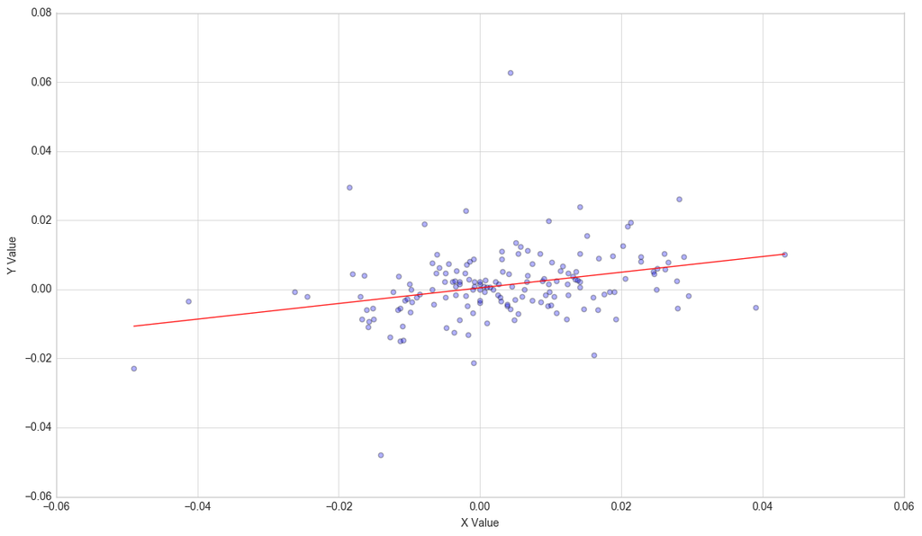

OLS Regression Results

| Dep. Variable: | y | R-squared: | 0.092 |
| --- | --- | --- | --- |
| Model: | OLS | Adj. R-squared: | 0.086 |
| Method: | Least Squares | F-statistic: | 16.36 |
| Date: | Fri, 15 Sep 2017 | Prob (F-statistic): | 8.10e-05 |
| Time: | 00:32:57 | Log-Likelihood: | 525.55 |
| No. Observations: | 164 | AIC: | -1047. |
| Df Residuals: | 162 | BIC: | -1041. |
| Df Model: | 1 |  |  |
| Covariance Type: | nonrobust |  |  |

|  | coef | std err | t | P>\|t\| | [0.025 | 0.975] |
| --- | --- | --- | --- | --- | --- | --- |
| const | 0.0004 | 0.001 | 0.523 | 0.601 | -0.001 | 0.002 |
| x1 | 0.2264 | 0.056 | 4.044 | 0.000 | 0.116 | 0.337 |

| Omnibus: | 71.002 | Durbin-Watson: | 1.869 |
| --- | --- | --- | --- |
| Prob(Omnibus): | 0.000 | Jarque-Bera (JB): | 880.897 |
| Skew: | 1.167 | Prob(JB): | 5.20e-192 |
| Kurtosis: | 14.112 | Cond. No. | 72.6 |

```python
from statsmodels import regression
import statsmodels.api as sm
import math

def linreg(X,Y):
    # Running the linear regression
    X = sm.add_constant(X)
    model = regression.linear_model.OLS(Y, X).fit() # OLS is ordinary least-squares
    a = model.params[0]
    b = model.params[1]
    X = X[:, 1]

    # Return summary of the regression and plot results
    X2 = np.linspace(X.min(), X.max(), 100)
    Y_hat = X2 * b + a
    plt.scatter(X, Y, alpha=0.3) # Plot the raw data
    plt.plot(X2, Y_hat, 'r', alpha=0.9);  # Add the regression line, colored in red
    plt.xlabel('X Value')
    plt.ylabel('Y Value')
    plt.show()
    return model

res = get_stock_data("00005",start,end,cols=1)
asset = pd.Series([i[1] for i in res["data"]],index=pd.DatetimeIndex([i[0] for i in res["data"]]))[::-1]
res = get_stock_data("00700",start,end,cols=1)
benchmark = pd.Series([i[1] for i in res["data"]],index=pd.DatetimeIndex([i[0] for i in res["data"]]))[::-1]

r_a = asset.pct_change()[1:]
r_b = benchmark.pct_change()[1:]

linreg(r_b.values, r_a.values).summary()
```

Note that linear regression is different from correlation, but both are measures of covariance.

- Linear regression gives us a specific linear model, but is limited to cases of linear dependence.
- Correlation is general to linear and non-linear dependencies, but doesn't give us an actual model.
- Linear regression can give us relationship between Y and many independent variables by making X multidimensional.

Keep in mind also that the calculated parameters $\alpha$, $\beta$ are only estimates as well.

The regression model relies on several assumptions:

- That the independent variable is not random.
- That the variance of the error term is constant across observations. This is important for evaluating the goodness of the fit.
- That the errors are not autocorrelated. The Durbin-Watson statistic detects this: if it is close to 2, there is no autocorrelation.
- That the errors are normally distributed. If this does not hold, we cannot use some of the statistics, such as the F-test.

When making a prediction based on the model, it's useful to report not only a single value but a confidence interval. The linear regression reports 95% confidence intervals for the regression parameters, which we can visualise using the `seaborn` library.

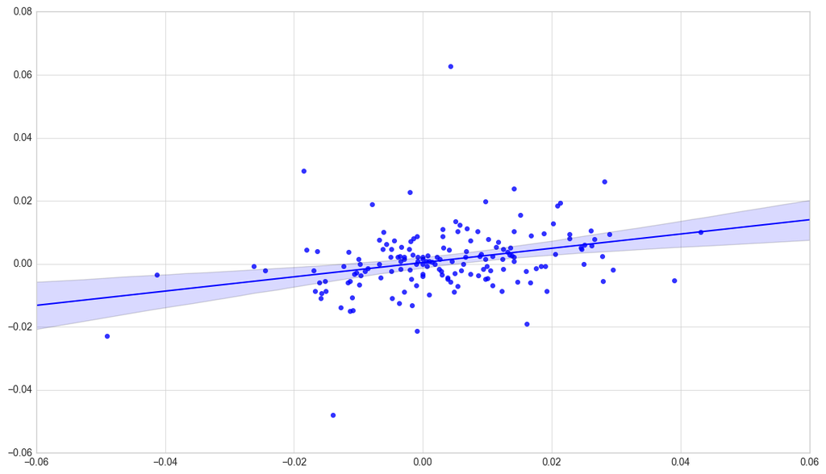

```python
sns.regplot(r_b.values, r_a.values)
plt.show()
```

The mathematics behind this regression method is in optimising the placement of the line of best fit. The *ordinary least squares* (OLS) method does so by solving the following minimisation problem, $$ \text{Find } \min_{a,b}Q(a,b)\text{ for }Q(a,b)=\sum_{i=1}^n\hat{\varepsilon}_i^2=\sum_{i=1}^n(Y_i-a-bX_i)^2\,. $$ The resulting values of $\hat{\alpha}$ and $\hat{\beta}$ are in closed form,

$$ \begin{align} \hat{\alpha}&=\bar{Y}-\hat{\beta}\bar{X}\,,\\ \hat{\beta}&=\frac{\sum_{i=1}^n(X_i-\bar{X})(Y_i-\bar{Y})}{\sum_{i=1}^n(X_i-\bar{X})^2}\\ &=\frac{\text{Cov}(X,Y)}{\text{Var}(X)}\,, \end{align} $$

where $\bar{X}$ and $\bar{Y}$ are the mean of samples $X$, $Y$ respectively, and $Cov$ denotes the sample covariance. Linear regression with OLS is called the *simple linear regression*.

## Multiple Linear Regression

We now generalise to $Y$ being a function of variables $X_1,...,X_k$. We want to express $$ Y_i=\alpha+\beta_0X_{1_i}+...+\beta_k X_{k_i}+\varepsilon_i $$ for observations $i=1,...,n$. To find the hyperplane of best fit using the OLS method, we now minimise $\sum_{i=1}^n\varepsilon_i^2$. Using a multivariate regression may be useful when two variables both correlated to another variable, such as Tencent and HSBC being correlated to the HSI. This method allows us to better gauge the significance between the two securities and the problem is known as confounding.

```python
# Load pricing data for two arbitrarily-chosen assets and 2800
start = '2017-02-01'
end = '2017-09-01'

res = get_stock_data("00005",start,end,cols=1)
asset1 = pd.Series([i[1] for i in res["data"]],index=pd.DatetimeIndex([i[0] for i in res["data"]]))[::-1]
asset1.name="HSBC"
res = get_stock_data("00700",start,end,cols=1)
asset2 = pd.Series([i[1] for i in res["data"]],index=pd.DatetimeIndex([i[0] for i in res["data"]]))[::-1]
asset2.name="Tencent"
res = get_stock_data("02800",start,end,cols=1)
benchmark = pd.Series([i[1] for i in res["data"]],index=pd.DatetimeIndex([i[0] for i in res["data"]]))[::-1]
benchmark.name="HSI"
```

```python
# First, run a linear regression on the two assets
slr = regression.linear_model.OLS(asset1, sm.add_constant(asset2)).fit()
print 'SLR beta of asset2:', slr.params[1]

# Run multiple linear regression using asset2 and 2800 as independent variables
mlr = regression.linear_model.OLS(asset1, sm.add_constant(np.column_stack((asset2, benchmark)))).fit()

prediction = mlr.params[0] + mlr.params[1]*asset2 + mlr.params[2]*benchmark
prediction.name = 'Prediction'

print 'MLR beta of asset2:', mlr.params[1], '\nMLR beta of HSI:', mlr.params[2]
```

```
SLR beta of asset2: 0.108837853008
MLR beta of asset2: -0.0646977146573
MLR beta of HSI: 4.57839339202
```

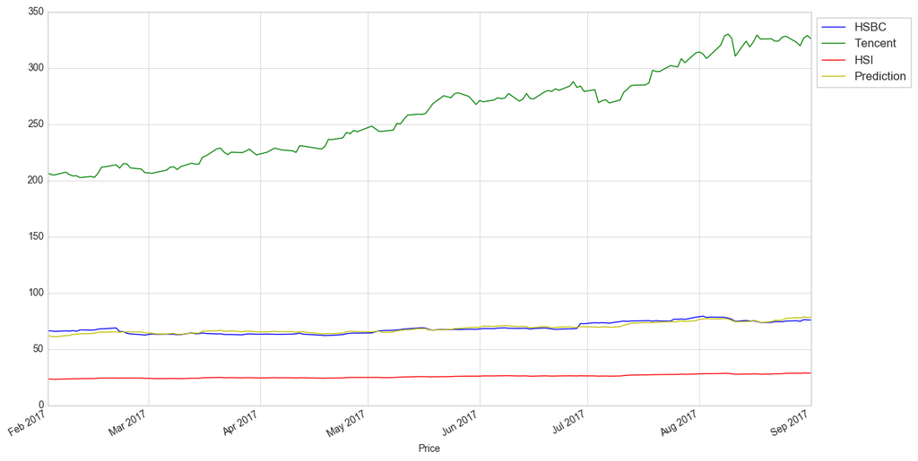

```python
# Plot the three variables along with the prediction given by the MLR
asset1.plot()
asset2.plot()
benchmark.plot()
prediction.plot(color='y')
plt.xlabel('Price')
plt.legend(bbox_to_anchor=(1,1), loc=2)
plt.show()
```

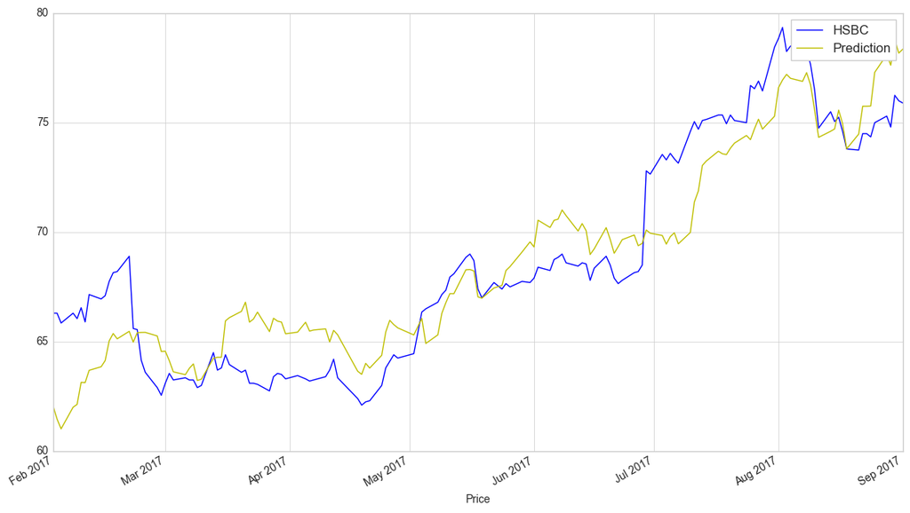

```python
# Plot only the dependent variable and the prediction to get a closer look
asset1.plot()
prediction.plot(color='y')
plt.xlabel('Price')
plt.legend()
plt.show()
```

```python
mlr.summary()
```

OLS Regression Results

| Dep. Variable: | HSBC | R-squared: | 0.826 |
| --- | --- | --- | --- |
| Model: | OLS | Adj. R-squared: | 0.824 |
| Method: | Least Squares | F-statistic: | 339.5 |
| Date: | Fri, 15 Sep 2017 | Prob (F-statistic): | 4.90e-55 |
| Time: | 00:33:03 | Log-Likelihood: | -315.18 |
| No. Observations: | 146 | AIC: | 636.4 |
| Df Residuals: | 143 | BIC: | 645.3 |
| Df Model: | 2 |  |  |
| Covariance Type: | nonrobust |  |  |

|  | coef | std err | t | P>\|t\| | [0.025 | 0.975] |
| --- | --- | --- | --- | --- | --- | --- |
| const | -32.1679 | 9.312 | -3.454 | 0.001 | -50.575 | -13.761 |
| x1 | -0.0647 | 0.022 | -2.877 | 0.005 | -0.109 | -0.020 |
| x2 | 4.5784 | 0.582 | 7.869 | 0.000 | 3.428 | 5.728 |

| Omnibus: | 16.367 | Durbin-Watson: | 0.094 |
| --- | --- | --- | --- |
| Prob(Omnibus): | 0.000 | Jarque-Bera (JB): | 11.360 |
| Skew: | 0.557 | Prob(JB): | 0.00341 |
| Kurtosis: | 2.210 | Cond. No. | 1.41e+04 |

The model assumptions are the same as those from linear regression. Additionally, the independent variables have to be linearly independent, else the coefficients $\beta_i$ cannot be solved uniquely.

The summarised statistics above tell us things about the fit. For example, the $R^2$ value tells us the fraction of the total variation of $Y$ that is explained by the model. The adjusted $R^2$ is preferred however as it corrects for the small increases in $R^2$ that occur when we add more regression variables to the model, even if they are not significantly correlated with the dependent variable. It is defined as $$ \text{Adj. }R^2=1-(1-R^2)\frac{n-1}{n-k-1}\,, $$ where $n$ is the number of observations and $k$ is the number of independent variables in the model.

## Linear correlation analysis

For two samples $X$, $Y$, the *correlation coefficient* is defined as $$ r=\frac{\text{Cov}(X,Y)}{\text{Cov}(X,X)\text{Cov}(Y,Y)}=\frac{\text{Cov}(X,Y)}{\sigma(X)\sigma(Y)} $$ where $\text{Cov}$ denotes the covariance and $\sigma$ is the standard deviation. Two sets of random data will have a correlation coefficient close to 0.

Correlation can be interpreted as a normalised covariance. It allows us to extract and compare information about $X$, $Y$ using their variance. `Numpy.cov()` and `Numpy.corrcoef()` can perform the desired calculations given two series.

```python
X = np.random.rand(50)
Y = 2 * X + 4

print 'Covariance of X and Y: \n' + str(np.cov(X, Y))
print 'Correlation of X and Y: \n' + str(np.corrcoef(X, Y))
```

```
Covariance of X and Y:
[[ 0.08527966  0.17055932]
 [ 0.17055932  0.34111864]]
Correlation of X and Y:
[[ 1.  1.]
 [ 1.  1.]]
```

Determining the correlation of assets is a useful tool in finance. For example, two stocks with a high correlation may allow prediction of future values. Let us look at Sunny Optical (02382), a manufacturer of 3D sensors for Apple and AAC Tech (02018).

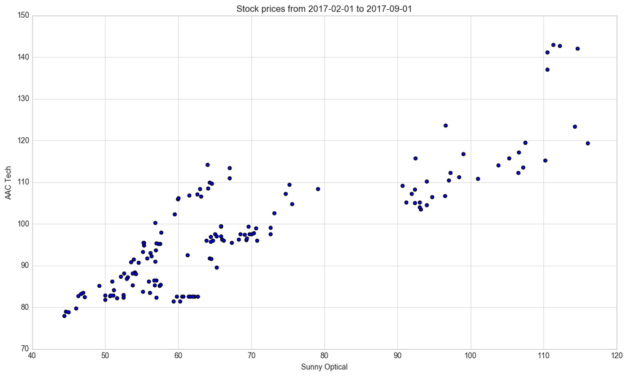

```
Correlation coefficients
Sunny Optical and AAC Tech:  0.854772484477
Sunny Optical and HSI:  0.939513217004
AAC Tech and HSI:  0.75155025435
```

```python
res = get_stock_data("02382",start,end,cols=1)
a1 = pd.Series([i[1] for i in res["data"]],index=pd.DatetimeIndex([i[0] for i in res["data"]]))[::-1]
a1.name="Sunny Optical"
res = get_stock_data("02018",start,end,cols=1)
a2 = pd.Series([i[1] for i in res["data"]],index=pd.DatetimeIndex([i[0] for i in res["data"]]))[::-1]
a2.name="AAC Tech"
a2 = a2.fillna(method="bfill")

plt.scatter(a1,a2)
plt.xlabel(a1.name)
plt.ylabel(a2.name)
plt.title('Stock prices from ' + start + ' to ' + end)
plt.show()
print "Correlation coefficients"
print a1.name+" and "+a2.name+": ", np.corrcoef(a1,a2)[0,1]
print a1.name + " and HSI: ", np.corrcoef(a1,benchmark)[0,1]
print a2.name + " and HSI: ", np.corrcoef(benchmark,a2)[0,1]
```

Uncorrelated assets are also desirable for constructing portfolios, since a depreciation in one will not pull another down with it. Thus a very stable return stream can be created when many uncorrelated assets are combined.

There are however limitations in looking at correlation. Since the variables are not normally distributed, high correlation now does not warrant high correlation in the future. Additionally, we have restricted to a particular time period, which might coincidentally appear to have some particular pattern. To avoid this, one should compute the correlation of two quantities over many historical time periods and examine the distibution of the correlation coefficient.

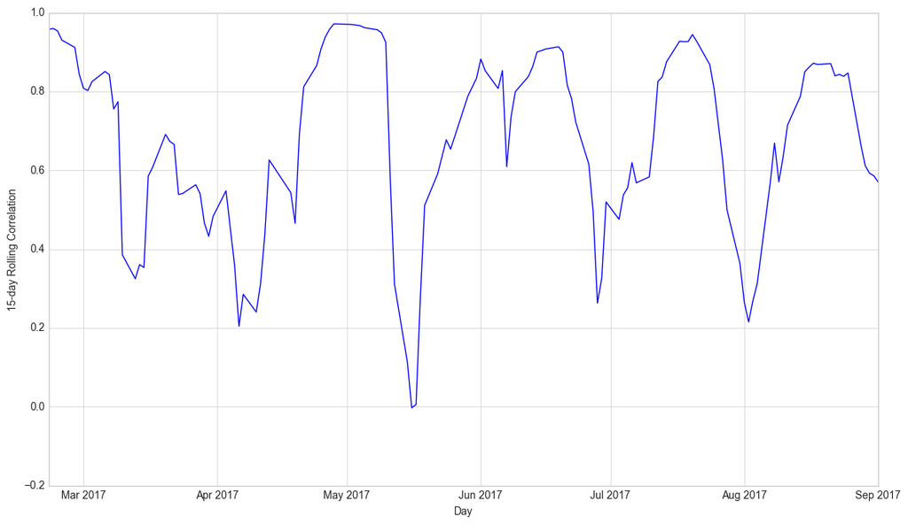

```python
rolling_correlation = a1.rolling(window=15).corr(a2)
plt.plot(rolling_correlation)
plt.xlabel('Day')
plt.ylabel('15-day Rolling Correlation')
plt.show()
```

There may also be non-linear relationships between the variables. For example, there may be a *lagged correlation* between two variables, i.e. one follows the other but with a delay. Alternatively, one might also be related to the rate of change of the other.

The correlation coefficient can be very sensitive to outliers as well. Suppose our second variable has Poisson-distributed noise instead:

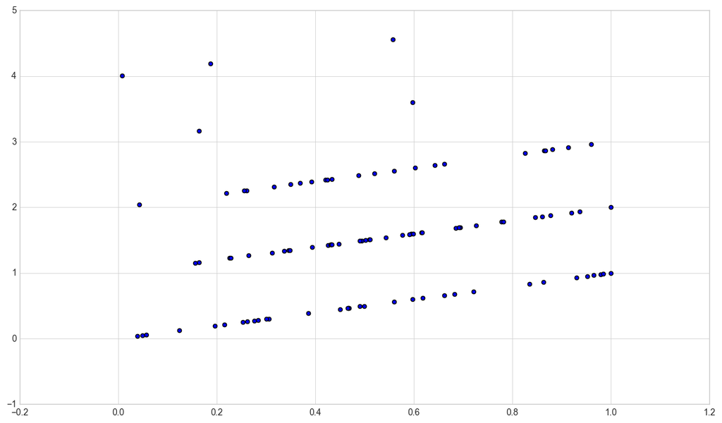

```
0.1729149417571243
```

```python
X = np.random.rand(100)
Y = X + np.random.poisson(size=100)

plt.scatter(X, Y)
plt.show()

np.corrcoef(X, Y)[0, 1]
```

## Residual analysis

Whenever we come to fitting data to a model, there will be discrepancies between the observed and predicted data. These discrepancies are known as *residuals* of the model, and can be used to check the basic assumptions that go into creating the model. The key assumptions to check for are

- Linear fit: whether the relationship is linear
- Homoscedastic: there should be no trend in variance in the data
- Independent and identically distributed (i.i.d.): the residuals of the regression should be i.i.d. and show no signs of serial correlation.

These residuals allow us to diagnose whether the relationship we have predicted is real or spurious.

Note that statistical error is a similar metric with one important difference: while residuals quantify the gap between a regression model predictions and the observed sample, statistical error is the difference between a regression model and the unobservable expected value. We use residuals in an attempt to estimate this error.

```python
# imports
import statsmodels.stats.diagnostic as smd
```

The definition of a residual is the difference between what is observed in the sample and what is predicted by the regression. For any residual $r_i$, this is $$ r_i=Y_i-\hat{Y}_i\,, $$ where $Y_i$ is the observed $Y$-value and $\hat{Y}_i$ is the predicted $Y$-value. We show this in a toy example:

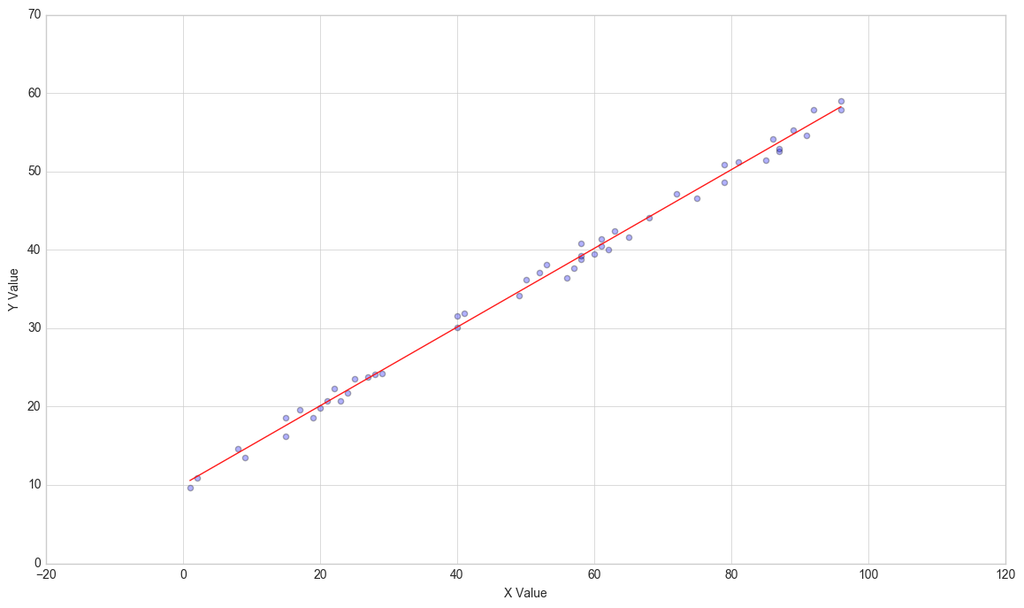

```
Line of best fit: Y = 10.0592103319 + 0.501962550821*X
Residuals:
[ 0.72593134 -0.28085321  1.48738417  0.98169172 -0.44520688 -1.12597228
 -1.11328378 -0.23377539  1.01327489 -0.75063363  1.6536141  -1.28216916
 -0.47093234 -1.38844038 -0.91212519 -1.08193677  1.19774877  0.50917303
 -0.18453093 -0.85472421  0.88731911 -0.97359947  0.99085145 -0.0753792
 -1.14096473 -1.03457136 -0.43789692 -0.35991606  0.04811304  0.94309901
 -0.3469494   0.87738198 -1.77194104  0.50205112  1.59860299  0.6997824
 -1.16014168 -0.09043164 -1.05685975  0.47803445  0.15492205 -0.79824025
  0.18791019  0.91888472  1.17000391  0.03563007  1.30939193 -1.11554475
  1.42989878  0.68632517]
```

```python
n = 50
X = np.random.randint(0, 100, n)
epsilon = np.random.normal(0, 1, n)

Y = 10 + 0.5 * X + epsilon

model = linreg(X,Y)

residuals = model.resid
plt.clf()
plt.errorbar(X,Y,xerr=0,yerr=[residuals,0*residuals],color='Green')
print "Line of best fit: Y = {0} + {1}*X".format(model.params[0], model.params[1])
print "Residuals:\n", residuals
```

To use residuals to diagnose our fitting, we can make a quick visual check by looking at the residual plot. This has the predicted values of the model versus the residuals themselves, and we are looking for a cloud of unrelated points.

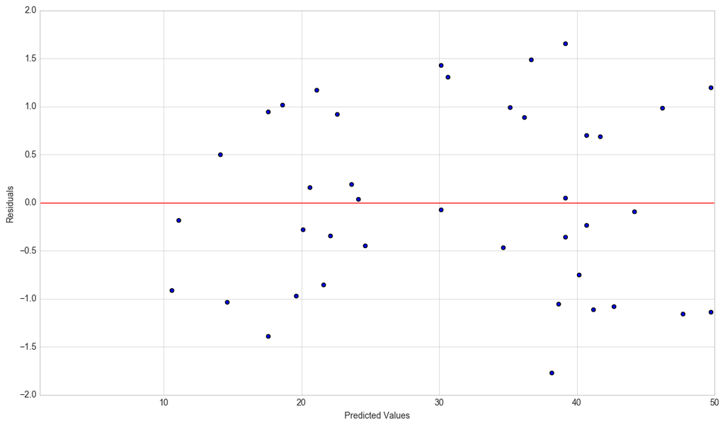

```python
plt.clf()
plt.scatter(model.predict(), residuals)
plt.axhline(0, color='red')
plt.xlabel('Predicted Values')
plt.ylabel('Residuals')
plt.xlim([1,50])
plt.show()
```

Let us now see what happens to the residuals when we try to fit non-linear data to a linear model. We should see the residual plot showing a distinct pattern. In general, a residual plot of a linear regression on a non-linear relationship will show bias and asymmetry with respect to residual = 0 line while a residual plot of a linear regression on a linear relationship will be generally symmetrical over the residual = 0 axis.

```
beta_0:  14.2669909567
beta_1:  -2.16623034106
```

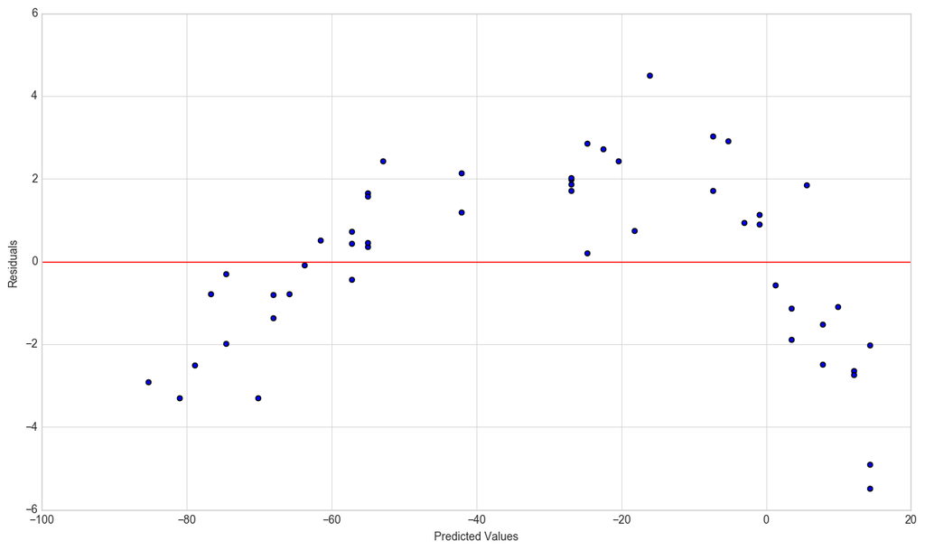

```python
n = 50
X = np.random.randint(0, 50, n)
epsilon = np.random.normal(0, 1, n)
Y_nonlinear = 10 - X**1.2 + epsilon

model = sm.OLS(Y_nonlinear, sm.add_constant(X)).fit()
B0, B1 = model.params
residuals = model.resid

print 'beta_0: ', B0
print 'beta_1: ', B1
plt.clf()
plt.scatter(model.predict(), residuals)
plt.axhline(0, color='red')
plt.xlabel('Predicted Values')
plt.ylabel('Residuals')
plt.show()
```

One of the main assumptions behind a linear regression is that the underlying data has a constant variance. If there are some parts of the data with a variance different from another part the data is not appropriate for a linear regression. *Heteroscedasticity* is a term that refers to data with non-constant variance, as opposed to *homoscedasticity*, when data has constant variance.

Significant heteroscedasticity invalidates linear regression results by biasing the standard error of the model. As a result, we can't trust the outcomes of significance tests and confidence intervals generated from the model and its parameters.

To avoid these consequences it is important to use residual plots to check for heteroscedasticity and adjust if necessary. Consider the following relationship between $X$ and $Y$:

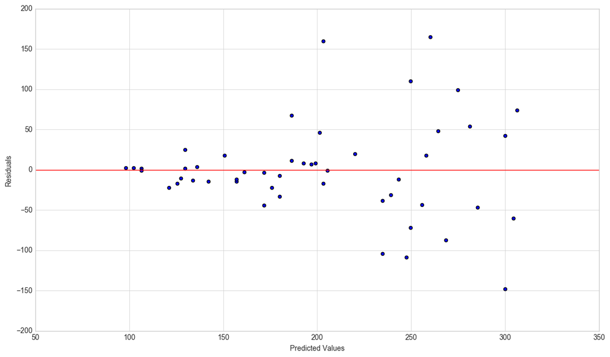

```python
n = 50
X = np.random.randint(0, 100, n)
epsilon = np.random.normal(0, 1, n)
Y_heteroscedastic = 100 + 2*X + epsilon*X

model = sm.OLS(Y_heteroscedastic, sm.add_constant(X)).fit()
B0, B1 = model.params
residuals = model.resid

plt.scatter(model.predict(), residuals)
plt.axhline(0, color='red')
plt.xlabel('Predicted Values')
plt.ylabel('Residuals')
plt.show()
```

Heteroscedasticity often manifests as this spread, giving us a tapered cloud in one direction or another. As we move along in the $x$-axis, the magnitudes of the residuals are clearly increasing. A linear regression is unable to explain this varying variability and the regression standard errors will be biased.

There are statistical tests for determining heteroscedasticity. Two common tests are the White test and the Breusch-Pagan hypothesis test. We will use the latter in this example, where the `statsmodels` package has a function `het_bruschpagan()` that performs the calculations for us.

```python
breusch_pagan_p = smd.het_breuschpagan(model.resid, model.model.exog)[1]
print breusch_pagan_p
if breusch_pagan_p > 0.05:
    print "The relationship is not heteroscedastic."
if breusch_pagan_p < 0.05:
    print "The relationship is heteroscedastic."
```

```
0.00150265050113
The relationship is heteroscedastic.
```

Here we set our confidence level to $\alpha=0.05$, so a Breusch-Pagan p-value below $0.05$ tells us that the relationship is heteroscedastic.

There are several ways to adjust for heteroscedasticity. The first is called *differences analysis*. This involves looking at the first-order differences between adjacent values, i.e. the changes from period to period of an independent variable rather than the raw values themselves. We then use the ensuing model on the differences.

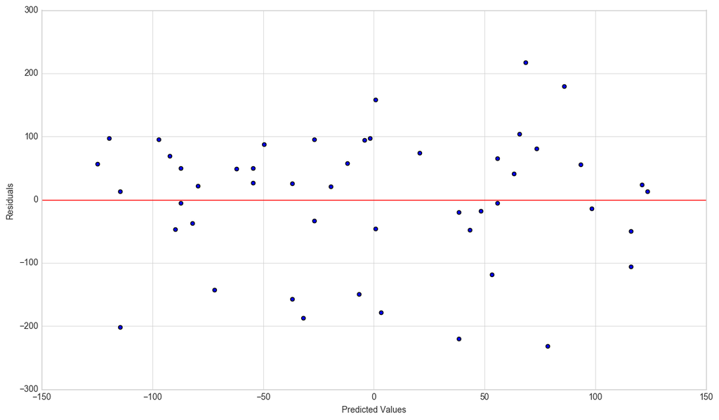

```
0.479498406885
The relationship is not heteroscedastic.
```

```python
# Finding first-order differences in Y_heteroscedastic
Y_heteroscedastic_diff = np.diff(Y_heteroscedastic)

# Fit again to first-order differences
model = sm.OLS(Y_heteroscedastic_diff, sm.add_constant(X[1:])).fit()
B0, B1 = model.params
residuals = model.resid

plt.clf()
plt.scatter(model.predict(), residuals)
plt.axhline(0, color='red')
plt.xlabel('Predicted Values')
plt.ylabel('Residuals')
plt.show()

breusch_pagan_p = smd.het_breuschpagan(residuals, model.model.exog)[1]
print breusch_pagan_p
if breusch_pagan_p > 0.05:
    print "The relationship is not heteroscedastic."
if breusch_pagan_p < 0.05:
    print "The relationship is heteroscedastic."
```

Note that since our new regression was computed on the differences between data, the regression output must be transformed back into the original scale in order to make our desired prediction. Since we regressed the differences, we can add our predicted difference onto the original data to get our estimate: $$ \hat{Y}_i=Y_{i-1}+\hat{Y}_{\text{diff}}\,. $$

The second way we can adjust for heteroscedasticity is by performing a log transformation. This will bring residuals closer together and ideally remove heteroscedasticity.

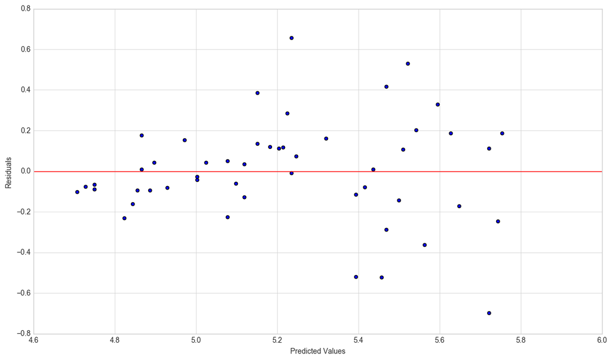

```
0.00743453732485
The relationship is heteroscedastic.
```

```python
# Taking the log of the previous data Y_heteroscedastic and saving it in Y_heteroscedastic_log
Y_heteroscedastic_log = np.log(Y_heteroscedastic)

# Fit log-transformed data
model = sm.OLS(Y_heteroscedastic_log, sm.add_constant(X)).fit()
B0, B1 = model.params
residuals = model.resid

plt.clf()
plt.scatter(model.predict(), residuals)
plt.axhline(0, color='red')
plt.xlabel('Predicted Values')
plt.ylabel('Residuals')
plt.show()

# Running and interpreting a Breusch-Pagan test
breusch_pagan_p = smd.het_breuschpagan(residuals, model.model.exog)[1]
print breusch_pagan_p
if breusch_pagan_p > 0.05:
    print "The relationship is not heteroscedastic."
if breusch_pagan_p < 0.05:
    print "The relationship is heteroscedastic."
```

To bring the estimates back to the original scale, we simply do $$ \hat{Y}=e^{\log\hat{Y}}\,. $$ The third and final way of reducing heteroscedasticity that we will examine is the *Box-Cox transformation*. This works by testing all values of $\lambda$ within the range $[-5,5]$ to see which makes the output $Y^{(\lambda)}$ most normally distributed: $$ Y^{(\lambda)}=\left\{ \begin{array}{ll} \frac{Y^\lambda-1}{\lambda} \qquad& \lambda\neq0\\ \log Y\qquad&\lambda=0 \end{array}\right.\,, $$ in which we use the $\lambda$ to transform the series as above. The `Scipy.stats` library has a function `boxcox()` that performs this operation. Note that the Box-Cox transformation can only be used if all the data is positive, since we need to take fractional powers and logs of $Y$.

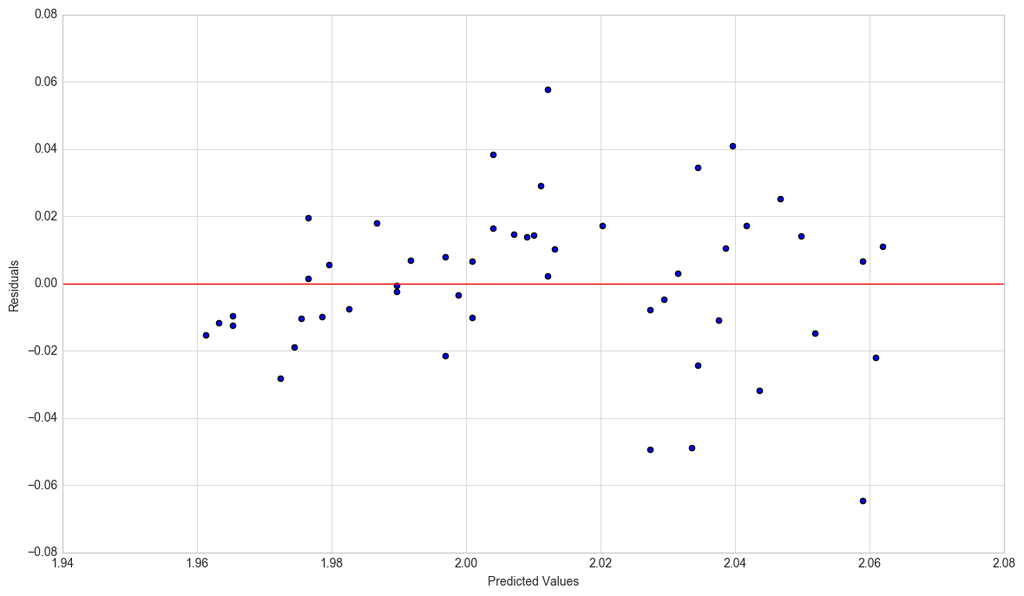

```
0.0275085063007
The relationship is heteroscedastic.
```

```python
# Finding a power transformation adjusted Y_heteroscedastic
Y_heteroscedastic_box_cox = scipy.stats.boxcox(Y_heteroscedastic)[0]

model = sm.OLS(Y_heteroscedastic_box_cox, sm.add_constant(X)).fit()
B0, B1 = model.params
residuals = model.resid

plt.clf()
plt.scatter(model.predict(), residuals);
plt.axhline(0, color='red')
plt.xlabel('Predicted Values');
plt.ylabel('Residuals');
plt.show()

# Running and interpreting a Breusch-Pagan test
breusch_pagan_p = smd.het_breuschpagan(residuals, model.model.exog)[1]
print breusch_pagan_p
if breusch_pagan_p > 0.05:
    print "The relationship is not heteroscedastic."
if breusch_pagan_p < 0.05:
    print "The relationship is heteroscedastic."
```

As before, we will require the inverse Box-Cox transformation of the estimated data, which is $$ \hat{Y}=(Y^{(\lambda)}\lambda+1)^{1/\lambda}\,. $$ There is a more advanced approach to dealing with heteroscedasticity called the generalized autoregressive conditional heteroscedasticity (GARCH) model, but this will not be covered here.

The final assumption we have to check is the autocorrelation of residuals. A series is autocorrelated when it is correlated with a delayed version of itself. For example, a series of daily high temperatures is autocorrelated, since today's temperature gives you information on tomorrow's temperature with reasonable confidence, while a series of fair dice rolls are not.

In finance, we assume that stock prices are usually autocorrelated while stock returns are independent from one day to the next. We represent a time dependency on previous values by $$ Y_i=Y_{i-1}+\epsilon\,. $$ If the residuals of a model are autocorrelated, you will be able to make predictions about adjacent residuals. In the case of $Y$, we know the data will be autocorrelated because we can make predictions based on adjacent residuals being close to one another.

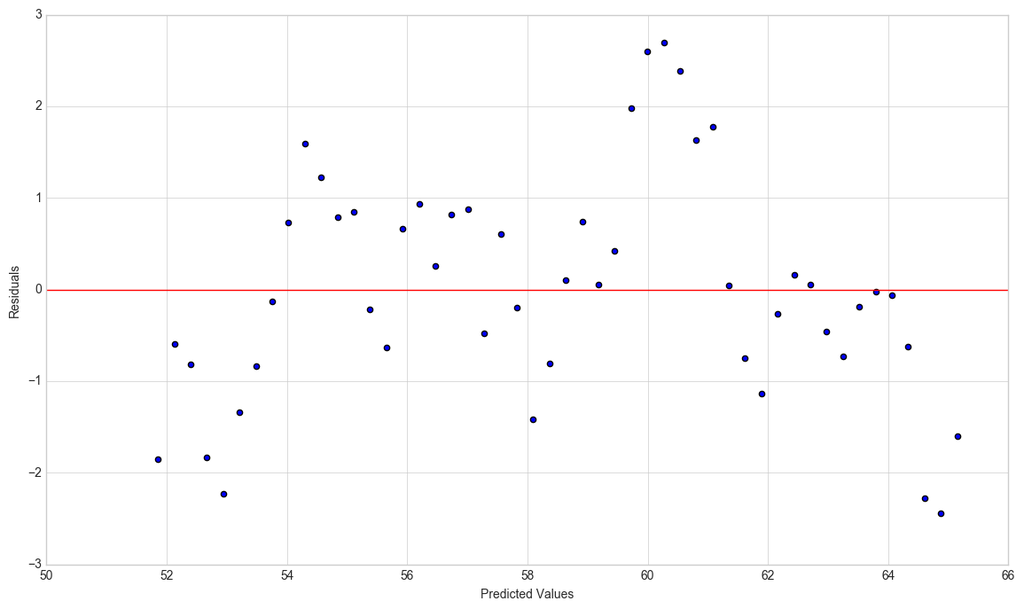

```python
n = 50
X = np.linspace(0, n, n)
Y_autocorrelated = [0]*n
Y_autocorrelated[0] = 50
for t in range(1, n):
    Y_autocorrelated[t] = Y_autocorrelated[t-1] + np.random.normal(0, 1)

# Regressing X and Y_autocorrelated
model = sm.OLS(Y_autocorrelated, sm.add_constant(X)).fit()
B0, B1 = model.params
residuals = model.resid

plt.clf()
plt.scatter(model.predict(), residuals);
plt.axhline(0, color='red')
plt.xlabel('Predicted Values');
plt.ylabel('Residuals');
plt.show()
```

Unlike heteroscedasticity, autocorrelation is not explicitly obvious and requires statistical testing to detect. The test we will use here is called the *Ljung-Box test*, which examines autocorrelation at all lag intervals below a specified maximum and returns arrays containing the outputs for every tested lag interval. We will use the `statsmodels.acorr_ljungbox()` function to do this with a max lag interval of $10$.

```python
ljung_box = smd.acorr_ljungbox(residuals, lags = 10)
print "Lagrange Multiplier Statistics:", ljung_box[0]
print "\nP-values:", ljung_box[1], "\n"

if any(ljung_box[1] < 0.05):
    print "The residuals are autocorrelated."
else:
    print "The residuals are not autocorrelated."
```

```
Lagrange Multiplier Statistics: [ 30.55460677  42.77005236  47.45277182  48.24316651  48.29781657
  48.99076971  50.44575383  52.19561714  52.9318251   52.97409757]

P-values: [  3.24600193e-08   5.15942300e-10   2.78426991e-10   8.39801226e-10
   3.08787076e-09   7.48773198e-09   1.18077096e-08   1.54287666e-08
   3.01119927e-08   7.52887502e-08]

The residuals are autocorrelated.
```

To adjust for autocorrelation, we can use similar methods as for heteroscedasticity. Let us first use the first-order difference method:

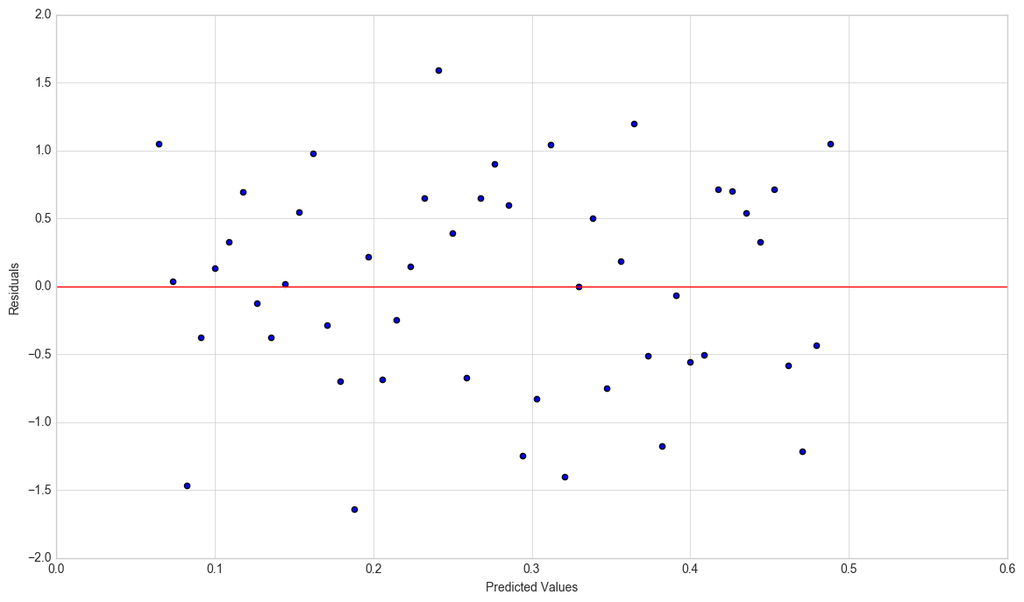

```
P-values: [ 0.38900678  0.07712516  0.16040914  0.2394366   0.24934283  0.32738866
  0.39084328  0.40137736  0.49527493  0.35957389]

The residuals are not autocorrelated.
```

```python
# Finding first-order differences in Y_autocorrelated
Y_autocorrelated_diff = np.diff(Y_autocorrelated)

model = sm.OLS(Y_autocorrelated_diff, sm.add_constant(X[1:])).fit()
B0, B1 = model.params
residuals = model.resid

plt.clf()
plt.scatter(model.predict(), residuals);
plt.axhline(0, color='red')
plt.xlabel('Predicted Values');
plt.ylabel('Residuals');
plt.show()

# Running and interpreting a Ljung-Box test
ljung_box = smd.acorr_ljungbox(residuals, lags = 10)
print "P-values:", ljung_box[1], "\n"

if any(ljung_box[1] < 0.05):
    print "The residuals are autocorrelated."
else:
    print "The residuals are not autocorrelated."
```

The other methods mentioned above may also be used, and remains as an exercise to see whether they deal with autocorrelation.

We conclude this section with an example that calculates the market beta between HSI and Tencent, and performs some residual analysis. To regress the two, we focus on their returns, not their price, and set HSI returns as our independent variable and Tencent returns as our outcome variable. The regression will give us a line of best fit of the form $$ \hat{r}_{\text{0700}}=\hat{\beta}_0+\hat{\beta}_1r_{\text{HSI}}\,. $$ Then $\hat{\beta}_1$ represents our market beta, since for every $r$-percent change in the returns of HSI, the predicted returns of Tencent will change by $\hat{\beta}_1$.

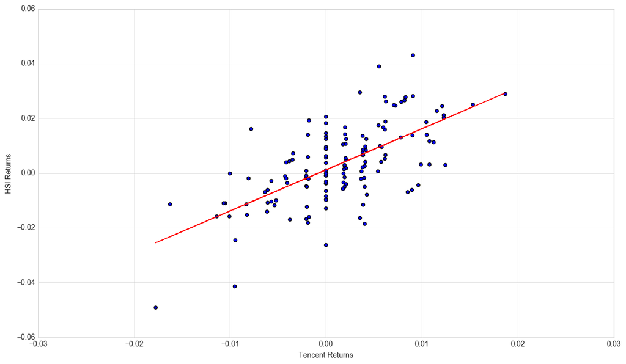

```
Estimated Tencent Beta: 1.5019474186
```

```python
res = get_stock_data("00700",start,end,cols=1)
asset = pd.Series([i[1] for i in res["data"]],index=pd.DatetimeIndex([i[0] for i in res["data"]]))[::-1]
res = get_stock_data("02800",start,end,cols=1)
benchmark = pd.Series([i[1] for i in res["data"]],index=pd.DatetimeIndex([i[0] for i in res["data"]]))[::-1]

r_a = asset.pct_change()[1:].values
r_b = benchmark.pct_change()[1:].values

# Regressing the benchmark b and asset a
r_b = sm.add_constant(r_b)
model = sm.OLS(r_a, r_b).fit()
r_b = r_b[:, 1]
B0, B1 = model.params

# Plotting the regression
A_hat = (B1*r_b + B0)
plt.scatter(r_b, r_a, alpha=1) # Plot the raw data
plt.plot(r_b, A_hat, 'r', alpha=1);  # Add the regression line, colored in red
plt.xlabel('Tencent Returns')
plt.ylabel('HSI Returns')
plt.show()

# Print our result
print "Estimated Tencent Beta:", B1

# Calculating the residuals
residuals = model.resid
```

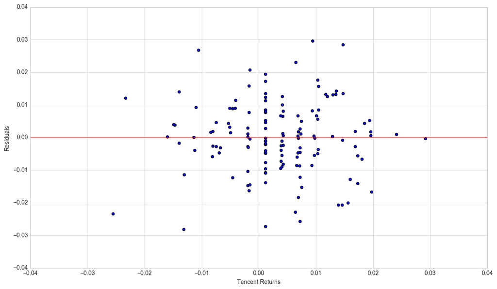

```
Lagrange Multiplier Statistic: 0.00587256336001
P-value: 0.938915782742
f-value: 0.00579179705638
f_p-value: 0.939442840926

The relationship is not heteroscedastic.
P-Values: [ 0.12207421  0.23568203  0.402282    0.51570688  0.62200708  0.50378169
  0.57986977  0.60329585  0.68437151  0.76138081  0.22371448  0.0447378
  0.06356851  0.00625775  0.0072972   0.00901203  0.00977133  0.01055367
  0.0145934   0.02000138  0.02785155  0.02715371  0.02025717  0.027673
  0.03427929  0.0282485   0.03700424  0.03798441  0.01507152  0.0203075
  0.02566998  0.03353775  0.03859973  0.04917183  0.06169052  0.0757698
  0.09211162  0.1025116   0.12326403  0.10452699]

The residuals are autocorrelated.
```

```python
plt.clf()
plt.scatter(model.predict(), residuals);
plt.axhline(0, color='red')
plt.xlabel('Tencent Returns');
plt.ylabel('Residuals');
plt.show()

bp_test = smd.het_breuschpagan(residuals, model.model.exog)

print "Lagrange Multiplier Statistic:", bp_test[0]
print "P-value:", bp_test[1]
print "f-value:", bp_test[2]
print "f_p-value:", bp_test[3], "\n"
if bp_test[1] > 0.05:
    print "The relationship is not heteroscedastic."
if bp_test[1] < 0.05:
    print "The relationship is heteroscedastic."

ljung_box = smd.acorr_ljungbox(r_a)
print "P-Values:", ljung_box[1], "\n"
if any(ljung_box[1] < 0.05):
    print "The residuals are autocorrelated."
else:
    print "The residuals are not autocorrelated."
```

## Statistical moments: skewness and kurtosis

A distribution is *symmetric* if the parts on either side of the mean are mirror images of each other. Otherwise, it is called *skewed*. For example, the normal distribution is symmetric. There is a measure of skewness, given by $$ S_K=\frac{n}{(n-1)(n-2)}\frac{\sum_{i=1}^n(X_i-\mu)^3}{\sigma^3}\,, $$ where $n$ is the number of observations, $\mu$ is the mean and $\sigma$ the standard deviation.

This gives the properties

- a unimodal (one mode) distribution is positively skewed if the mean > median > mode,
- a unimodal distribution is negatively if mean < median < mode.

```
Skew: -0.236159024673
Mean: 0.00141020041069
Median: 0.0018281535649
```

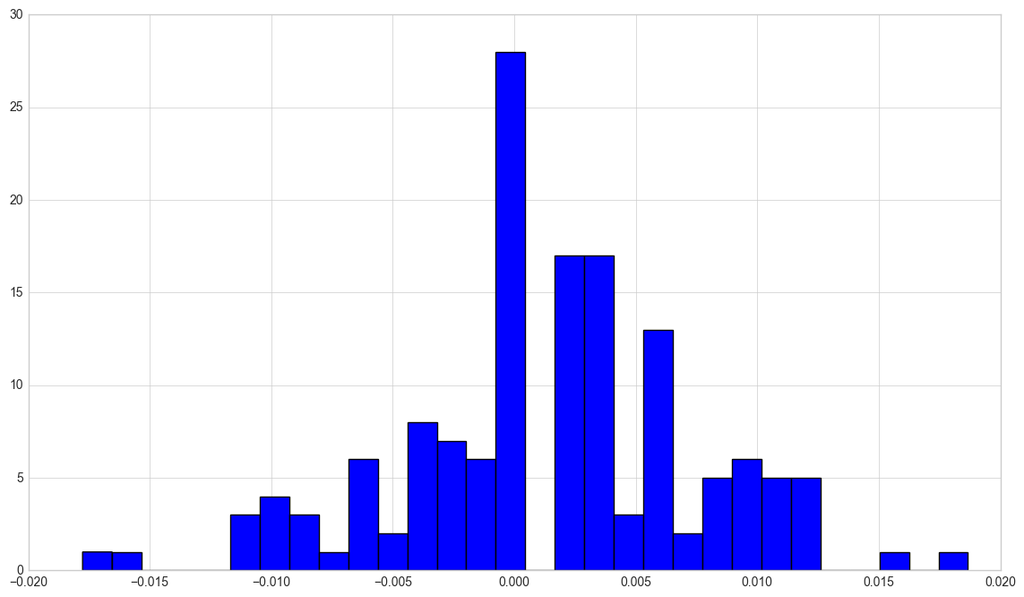

```python
res = get_stock_data("02800",start,end,cols=1)
pricing = pd.Series([i[1] for i in res["data"]],index=pd.DatetimeIndex([i[0] for i in res["data"]]))[::-1]
returns = pricing.pct_change()[1:]

print 'Skew:', scipy.stats.skew(returns)
print 'Mean:', np.mean(returns)
print 'Median:', np.median(returns)

plt.clf()
plt.hist(returns, 30)
plt.show()
```

Kurtosis attempts to measure the shape of the deviation from the mean. Generally, it describes how peaked a distribution is compared the the normal distribution, which is *mesokurtic*. All normal distributions, regardless of mean and variance, have a kurtosis of 3. A distribution is *leptokurtic* if it has a kurtosis of greater than 3, which makes it exhibit a highly peaked and fat-tailed shape. A distribution is *platykurtic* if it has kurtosis of less than 3, which makes it look broad.

The formula for kurtosis is given by $$ K=\left(\frac{n(n+1)}{(n-1)(n-2)(n-3)}\frac{\sum_{i=1}^n(X_i-\mu)^4}{\sigma^4}\right)\,, $$ where $n$ is the number of observations. The `Scipy.stats.kurtosis()` function calculates the *excess kurtosis*, which is given by $$ K_E=\left(\frac{n(n+1)}{(n-1)(n-2)(n-3)}\frac{\sum_{i=1}^n(X_i-\mu)^4}{\sigma^4}\right)-\frac{3(n-1)^2}{(n-2)(n-3)}\,. $$ In the limit of large $n$, this reduces to $$ K_E\approx\frac{1}{n}\frac{\sum_{i=1}^n(X_i-\mu)^4}{\sigma^4}-3\,. $$ There is a general family that variance, skewness and kurtosis fall under. This is the standardised moment: we define the $k$*th standardised moment* as $$ \frac{\mathbb{E}[(X-\mathbb{E}[X])^k]}{\sigma^k}\,. $$ Then variance, skewness and kurtosis are the 2nd, 3rd and 4th standardised moments (the first is always zero). They can be used to quantify how close to normal a distribution is.

Each test is written a little differently across different programming languages; it might be the null or alternative hypothesis that the tested data come from a normal distribution. Thus we first calibrate the test by checking it on simulated data and making sure it gives the right answer.

```python
from statsmodels.stats.stattools import jarque_bera

N = 1000
M = 1000

pvalues = np.ndarray((N))

for i in range(N):
    # Draw M samples from a normal distribution
    X = np.random.normal(0, 1, M);
    _, pvalue, _, _ = jarque_bera(X)
    pvalues[i] = pvalue

# count number of pvalues below our default 0.05 cutoff
num_significant = len(pvalues[pvalues < 0.05])

print float(num_significant) / N
```

```
0.051
```

We expect a 5% error at a 0.05 significance level, so this matches closely. Let us now try it on our HSI returns data.

```python
_, pvalue, _, _ = jarque_bera(returns)

if pvalue > 0.05:
    print 'The returns are likely normal.'
else:
    print 'The returns are likely not normal.'
```

```
The returns are likely normal.
```

## Confidence intervals

In statistics, we perform samples in order to gain information on the parameters that govern the distribution of the data we are sampling from. Confidence intervals allow us to determine e.g. how accurately our sample mean estimates the population mean. More precisely, a $100\gamma\%$ confidence interval for a parameter $\theta$ means that for a large number of samples, $100\gamma\%$ of them will cover the true value of $\theta$.

Suppose we first look towards the variance in our sample. We define the *standard error* as $$ SE = \frac{\sigma}{\sqrt{n}}\,, $$ under the conditions that the estimation is unbiased, and the data normal and independent. This is calculated using `Scipy.stats.sem()`. Note that this function has a degree of freedom parameter `ddof` that becomes less relevant for large samples and can be set to zero.

To get our confidence interval, we then ask how many standard deviations contain 95% of the mass. This turns out to be the interval $[-1.96,1.96]$. So the 95% c.i. for the mean is $(\mu-1.96SE,\mu+1.96SE)$. Note that this requires our data to be normally distributed. For large enough samples $(\gtrsim 30)$ the Central Limit Theorem can be applied so this works. For smaller samples a $t$-distribution is safer to use, with a degree of freedom equal to the sample size - 1.

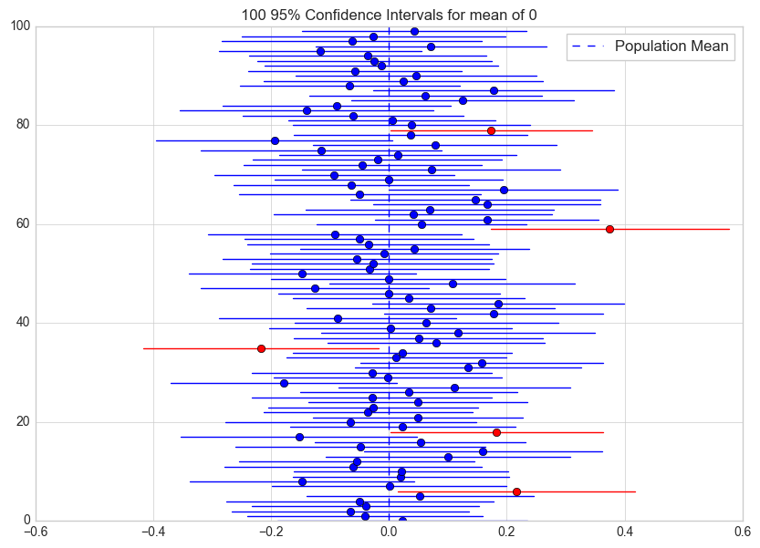

```python
np.random.seed(8309)
n = 100 # number of samples to take
samples = [np.random.normal(loc=0, scale=1, size=100) for _ in range(n)]

plt.clf()
fig, ax = plt.subplots(figsize=(10, 7))
for i in range(n):
    sample_mean = np.mean(samples[i])  # calculate sample mean
    se = scipy.stats.sem(samples[i])  # calculate sample standard error
    h = se*scipy.stats.t.ppf((1+0.95)/2, len(samples[i])-1) # calculate t; 2nd param is d.o.f.
    sample_ci = [sample_mean - h, sample_mean + h]
    if ((sample_ci[0] <= 0) and (0 <= sample_ci[1])):
        plt.plot((sample_ci[0], sample_ci[1]), (i, i), color='blue', linewidth=1);
        plt.plot(np.mean(samples[i]), i, 'bo');
    else:
        plt.plot((sample_ci[0], sample_ci[1]), (i, i), color='red', linewidth=1);
        plt.plot(np.mean(samples[i]), i, 'ro');
plt.axvline(x=0, ymin=0, ymax=1, linestyle='--', label = 'Population Mean');
plt.legend(loc='best');
plt.title('100 95% Confidence Intervals for mean of 0');
plt.show()
```

The computation of a standard deviation, standard error, and confidence interval all rely on certain assumptions. If these are violated, then the 95% confidence interval will not necessarily contain the population parameter 95% of the time. In this case, we say that the c.i. is *miscalibrated*.

For example, if the data generating process is autocorrelated, then estimates of standard deviation will be wrong. This is due to new values being dependent on previous values, so series that are already far from the mean are likely to stay far from the mean. This produces more extreme values that are not normally distributed. To show this, let us generate autocorrelated data using the following process: $$ \begin{align} X_t&=\theta X_{t-1}+\epsilon\\ \epsilon&\sim\mathcal{N}(0,1)\,,\qquad X_0=0\,. \end{align} $$

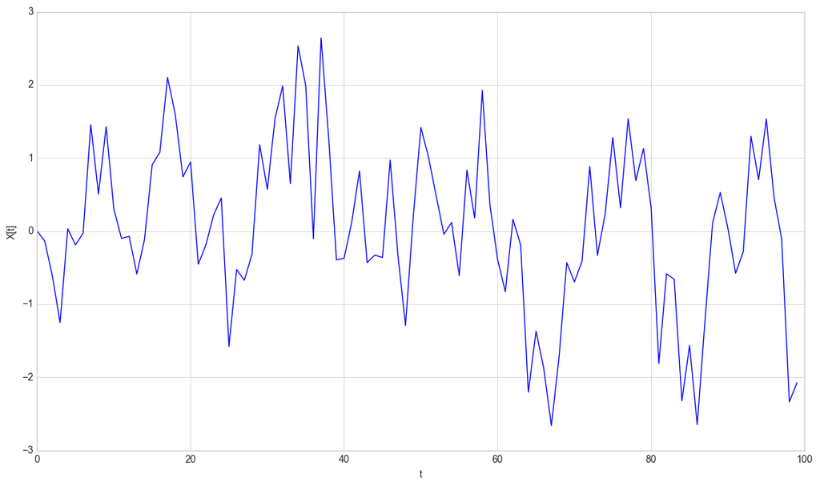

```python
def generate_autocorrelated_data(theta, mu, sigma, N):
    # Initialize the array
    X = np.zeros((N, 1))

    for t in range(1, N):
        # X_t = theta * X_{t-1} + epsilon
        X[t] = theta * X[t-1] + np.random.normal(mu, sigma)
    return X

X = generate_autocorrelated_data(0.5, 0, 1, 100)

plt.clf()
plt.plot(X);
plt.xlabel('t');
plt.ylabel('X[t]');
plt.show()
```

Analytically, one can show that $\mathbb{E}[X_t]=0$. So let us check the calibration of confidence intervals, using two helper functions which compute a naive interval for some input data, and check whether the interval contains the true mean, 0.

Then we run many trials, sampling some data in each, compute a confidence interval, and then check if the confidence interval contains the population mean. We'll keep a running tally, and we should expect to see 95% of the trials succeed if the intervals are calibrated correctly.

```python
def compute_unadjusted_interval(X):
    T = len(X)
    # Compute mu and sigma MLE
    mu = np.mean(X)
    sigma = np.std(X)
    SE = sigma / np.sqrt(T)
    # Compute the bounds
    return scipy.stats.norm.interval(0.95, loc=mu, scale=SE)

# We'll make a function that returns true when the computed bounds contain 0
def check_unadjusted_coverage(X):
    l, u = compute_unadjusted_interval(X)
    # Check to make sure l <= 0 <= u
    if l <= 0 and u >= 0:
        return True
    else:
        return False

T = 100
trials = 500
times_correct = 0
for i in range(trials):
    X = generate_autocorrelated_data(0.5, 0, 1, T)
    if check_unadjusted_coverage(X):
        times_correct += 1

print 'Empirical Coverage: ', times_correct/float(trials)
print 'Expected Coverage: ', 0.95
```

```
Empirical Coverage:  0.712
Expected Coverage:  0.95
```

As predicted, the empirical coverage is much less than the required coverage, and thus is an incorrect confidence interval.

## Spearman rank coefficient

We already know of a way to determine whether two sets of data move linearly, and how to find their linear relationship. The *Spearman rank correlation coefficient* allows us to determine *whether* two sets of data move together in general. It is useful when we have data sets that have different units, and thus not linearly related (e.g. the price of a square plot of land and its side length, since the price is more likely to be linear in the area). It is also suitable for data sets which do not satisfy the assumptions that other tests require, such as the observations being normally distributed needed for a t-test.

In computing the spearman rank coefficient, we deal with *ranks* of data rather than the raw data themselves. The process of ranking is a transformation that replaces the values of a dataset by their rank (the list position) when the data are sorted. For example, if we have `l = [10, 9, 5, 7, 5]`, then a possible ranking of `l` is `[5, 4, 1.5, 3, 1.5]`, using an averaging method. Here the entry `5` is in both the 1st and 2nd rank of the list, and so is averaged to `1.5`.

```python
# Example of ranking data
l = [10, 9, 5, 7, 5]
print 'Raw data: ', l
print 'Ranking: ', list(scipy.stats.rankdata(l, method='average'))
```

```
Raw data:  [10, 9, 5, 7, 5]
Ranking:  [5.0, 4.0, 1.5, 3.0, 1.5]
```

The Spearman rank correlation for two datasets $X$, $Y$ is given by $$ r_S=1-\frac{6\sum_{i=1}^nd_i^2}{n(n^2-1)}\,, $$ where $d_i=\text{rk}(X_i)-\text{rk}(Y_i)$ is the difference in rank of the $i$th pair of observations. One can show that $-1\leq r_S\leq 1$. A positive value indicates a positive relationship between the variables, while a negative value indicates an inverse relationship. A value of 0 implies the absense of any monotonic relationship. Note that this does not mean there is no relationship, for instance, if $Y$ is equal to $X$ with a delay of 2, they are related simply and precisely, but their $r_S$ can be close to zero:

```python
n=100
runs=500
spearman_dist = []
for i in range(runs):
    X = np.random.poisson(size=n+2)
    Y=X[2:]
    Xrank = scipy.stats.rankdata(X[:100], method='average')
    Yrank = scipy.stats.rankdata(Y, method='average')

    diffs = Xrank - Yrank # order doesn't matter since we'll be squaring these values
    spearman_dist.append(1 - 6*sum(diffs*diffs)/(n*(n**2 - 1)))
print np.mean(spearman_dist)
```

```
0.111084824482
```

```
Spearman Rank Coefficient: 0.877365586559
Correlation coefficient: 0.773592049592
```

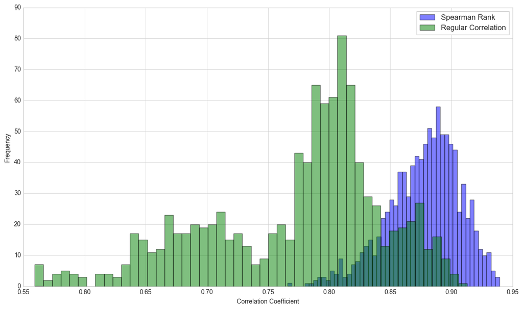

```python
## Let's see an example of this
n = 100

def compare_correlation_and_spearman_rank(n, noise):
    X = np.random.poisson(size=n)
    Y = np.exp(X) + noise * np.random.normal(size=n)

    Xrank = scipy.stats.rankdata(X, method='average')
    # n-2 is the second to last element
    Yrank = scipy.stats.rankdata(Y, method='average')

    diffs = Xrank - Yrank # order doesn't matter since we'll be squaring these values
    r_s = 1 - 6*sum(diffs*diffs)/(n*(n**2 - 1))
    c_c = np.corrcoef(X, Y)[0,1]

    return r_s, c_c

experiments = 1000
spearman_dist = np.ndarray(experiments)
correlation_dist = np.ndarray(experiments)
for i in range(experiments):
    r_s, c_c = compare_correlation_and_spearman_rank(n, 1.0)
    spearman_dist[i] = r_s
    correlation_dist[i] = c_c

print 'Spearman Rank Coefficient: ' + str(np.mean(spearman_dist))
# Compare to the regular correlation coefficient
print 'Correlation coefficient: ' + str(np.mean(correlation_dist))

plt.clf()
plt.hist(spearman_dist, bins=50, alpha=0.5)
plt.hist(correlation_dist, bins=50, alpha=0.5)
plt.legend(['Spearman Rank', 'Regular Correlation'])
plt.xlabel('Correlation Coefficient')
plt.ylabel('Frequency');
plt.show()
```

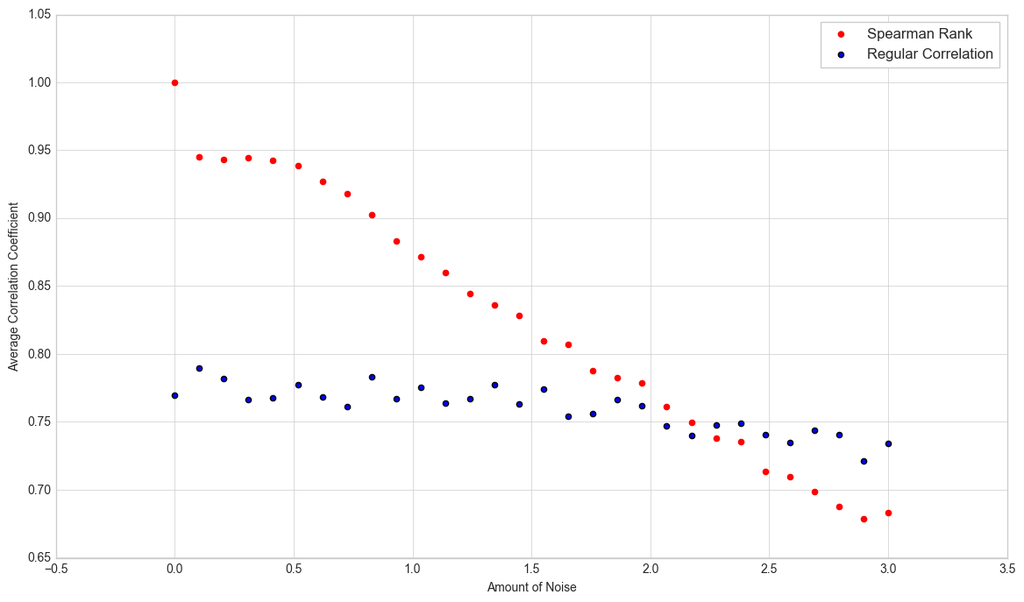

```python
n = 100
noises = np.linspace(0, 3, 30)
experiments = 100
spearman = np.ndarray(len(noises))
correlation = np.ndarray(len(noises))

for i in range(len(noises)):
    # Run many experiments for each noise setting
    rank_coef = 0.0
    corr_coef = 0.0
    noise = noises[i]
    for j in range(experiments):
        r_s, c_c = compare_correlation_and_spearman_rank(n, noise)
        rank_coef += r_s
        corr_coef += c_c
    spearman[i] = rank_coef/experiments
    correlation[i] = corr_coef/experiments

plt.clf()
plt.scatter(noises, spearman, color='r')
plt.scatter(noises, correlation)
plt.legend(['Spearman Rank', 'Regular Correlation'])
plt.xlabel('Amount of Noise')
plt.ylabel('Average Correlation Coefficient')
plt.show()
```

So we see that at moderate amounts of noise, the Spearman rank coefficient holds out better. Note that in the case where there might be a lagged relationship, one can simply use a combination of regular and Spearman correlation with a range of offsets to test if there is such a relationship.

The `spearmanr()` function in the `Scipy.stats` library allows us to directly calculate the Spearman coefficient. It returns 2 values: the coefficient and the p-value.

We conclude this section with the following example. Consider the expense and Sharpe ratio of a mutual fund. The (ex-ante) *Sharpe ratio* is a measure for calculating risk-adjusted return, given by $$ S_a=\frac{\mathbb{E}[R_a-R_b]}{\sigma_a}=\frac{\mathbb{E}[R_a-R_b]}{\sqrt{\text{var}(R_a-R_b)}}\,, $$ where $R_a$ is the portfolio return of the asset, $R_b$ the return of a benchmark asset (e.g. risk-free rate of return, or the return of an index such as the HSI), and $\sigma_a$ is the standard deviation of the asset excess return.

We want to ask whether spending more money on administration, management, etc. of a mutual fund lowers its risk or increases its returns. We will use the sample data `samples\mutual_fund_data.csv`.

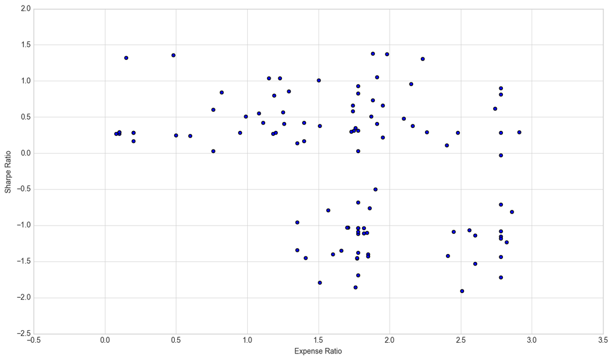

```
Spearman Rank Coefficient:  -0.237573932355
p-value:  0.0167465097116
```

```python
import csv

def local_csv(fname):
    res = {}
    with open(fname) as csvfile:
        csvread = csv.DictReader(csvfile)
        for row in csvread:
            for key, val in row.iteritems():
                try:
                    tval = float(val)
                except(ValueError):
                    tval = val

                if key in res:
                    res[key].append(tval)
                else:
                    res[key]=[tval]
    return pd.DataFrame(data = res)

mutual_fund_data = local_csv('samples/mutual_fund_data.csv')
expense = mutual_fund_data['Annual Expense Ratio'].values
sharpe = mutual_fund_data['Three Year Sharpe Ratio'].values

plt.clf()
plt.scatter(expense, sharpe)
plt.xlabel('Expense Ratio')
plt.ylabel('Sharpe Ratio')
plt.show()

r_S = scipy.stats.spearmanr(expense, sharpe)
print 'Spearman Rank Coefficient: ', r_S[0]
print 'p-value: ', r_S[1]
```

Our p-value is below the cutoff, which means that we should accept the hypothesis that the two are correlated. The negative coefficient indicates that there is a negative correlation, i.e. more expensive mutual funds have worse sharpe ratios. However, there is some weird clustering in the data: there are expensive groups with low sharpe ratios, and a main group whose sharpe ratio is unrelated to the expense. Further analysis would be required to draw a solid conclusion.

## p-Hacking and multiple comparisons bias

Multiple comparisons bias is a pervasive problem in statistics, data science, and in general forecasting/predictions. It occurs when we perform an increasing amount of tests in order to reach an outcome that we want or expect, but in the process ignoring the multitude of tests that failed. For example, we might have a trial for a medicine that cures a cold, where many people take multiple medicines at once to try and get rid of the symptoms. This may lead us to think that a certain medicine worked, but actually they may have just gotten better by themselves.

p-Hacking bias occurs when one treats different p-values as more or less significant. This results in more false positives and instead we should only treating p-values as binary.

Note how both biases do not stem from statistical testing and p-values itself but rather how we use them in certain situations.

```python
# Setting a cutoff of 5% means that there is a 5% chance
# of us getting a significant p-value given no relationship
# in our data (false positive).
# NOTE: This is only true if the test's assumptions have been
# satisfied and the test is therefore properly calibrated.
# All tests have different assumptions.
cutoff = 0.05

X = pd.Series(np.random.normal(0, 1, 100))
Y = X + np.random.normal(0, 1, 100)

r_s = scipy.stats.spearmanr(Y, X)
print 'Spearman Rank Coefficient: ', r_s[0]
if r_s[1] < cutoff:
    print 'There is significant evidence of a relationship.'
else:
    print 'There is not significant evidence of a relationship.'
```

```
Spearman Rank Coefficient:  0.72895289529
There is significant evidence of a relationship.
```

Let us now perform an experiment where we look at instances where the p-value of a Spearman correlation test between all pairs in our data is below a defined cutoff of 5%. In other words, we create $N$ normally distributed series of length $T$, run the Spearman correlation test on all pairs of series, then see how many returns a p-value below our cutoff.

To see how many we expect, note that there are $\frac{N(N-1)}{2}$ pairs of $N$ objects. So we should see `N(N-1)/2 * 0.05=9.5` pairs. Let us perform the experiment 100 times.

```python
df = pd.DataFrame()
N = 20
T = 100
cutoff= 0.05

for i in range(N):
    X = np.random.normal(0, 1, T)
    X = pd.Series(X)
    name = 'X%s' % i
    df[name] = X

def do_experiment(N, T, cutoff=0.05):
    df = pd.DataFrame()

    # Make random data
    for i in range(N):
        X = np.random.normal(0, 1, T)
        X = pd.Series(X)
        name = 'X%s' % i
        df[name] = X

    significant_pairs = []

    # Look for relationships
    for i in range(N):
        for j in range(i+1, N):
            Xi = df.iloc[:, i]
            Xj = df.iloc[:, j]

            results = scipy.stats.spearmanr(Xi, Xj)

            pvalue = results[1]

            if pvalue < cutoff:
                significant_pairs.append((i, j))

    return significant_pairs


num_experiments = 100

results = np.zeros((num_experiments,))

for i in range(num_experiments):
    # Run a single experiment
    result = do_experiment(20, 100, cutoff=cutoff)

    # Count how many pairs
    n = len(result)

    # Add to array
    results[i] = n
```

```python
print "Observed: " + str(np.mean(results))
print "Expected: " + str(N*(N-1) / 2 * cutoff)
```

```
Observed: 9.38
Expected: 9.5
```

What's happening here is that p-values should be uniformly distributed, since the data should all be uncorrelated. Thus they carry no information whatsoever and should be equally likely to be 0.01 as 0.99. We then expect a certain percentage of p-values to be underneath any chosen threshold. The lower the threshold the fewer will pass the test.

To see that this is true, let us examine the distribution of p-values produced from the experiment. Note that the amount of p-values produced scales as $O(N^2)$, so we do not require a lot of tests to be performed in order to produce a well-resolved distribution.

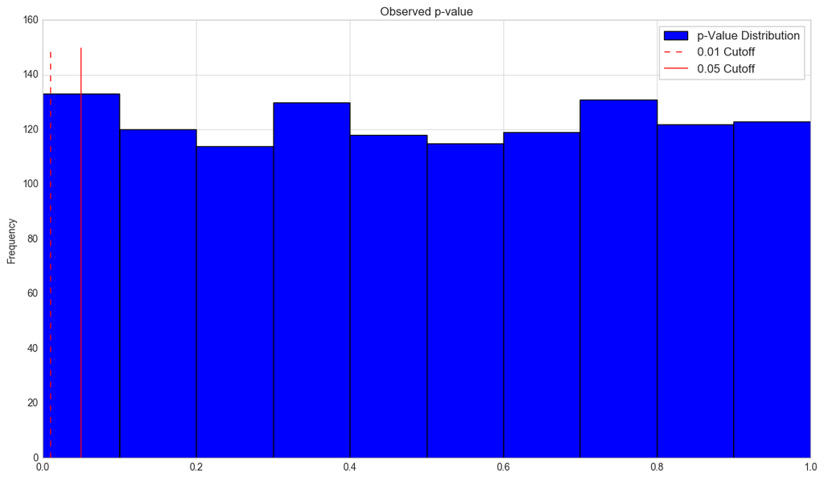

```python
def get_pvalues_from_experiment(N, T):
    df = pd.DataFrame()

    # Make random data
    for i in range(N):
        X = np.random.normal(0, 1, T)
        X = pd.Series(X)
        name = 'X%s' % i
        df[name] = X

    pvalues = []

    # Look for relationships
    for i in range(N):
        for j in range(i+1, N):
            Xi = df.iloc[:, i]
            Xj = df.iloc[:, j]

            results = scipy.stats.spearmanr(Xi, Xj)

            pvalue = results[1]

            pvalues.append(pvalue)

    return pvalues

pvalues = get_pvalues_from_experiment(50, 100)

plt.clf()
plt.vlines(0.01, 0, 150, colors='r', linestyle='--', label='0.01 Cutoff')
plt.vlines(0.05, 0, 150, colors='r', label='0.05 Cutoff')
plt.hist(pvalues, label='p-Value Distribution')
plt.legend()
plt.ylabel('Frequency')
plt.title('Observed p-value');
plt.show()
```

So we see that with a lower cutoff, we should expect to see fewer false positives. Let us check that with our experiment again.

```python
results = np.zeros((num_experiments,))
cutoff = 0.01

for i in range(num_experiments):
    # Run a single experiment
    result = do_experiment(20, 100, cutoff=cutoff)

    # Count how many pairs
    n = len(result)

    # Add to array
    results[i] = n
```

```python
print "Observed: " + str(np.mean(results))
print "Expected: " + str(N*(N-1) / 2 * cutoff)
```

```
Observed: 1.93
Expected: 1.9
```

Note that there is a sensitivity/specificity tradeoff however when adjusting the p-value cutoff. A lower cutoff decreases the rate of false positives, but also decreases the chance of finding a real relationship (true positives).

We cannot really eliminate mulitple comparisons bias, but we can reduce its impact. There are two options to do so:

- Run fewer tests: rather than brute-forcing hypothesis tests, we should spend time exploring the data and use our knowledge of the system to create an effective hypothesis. Testing this hypothesis on new data will then allow us to know how consistent its effect is.
- Adjustment factors and Bon Ferroni correction: when we have no other choice but to run many tests, there are ways to adjust the cutoffs such that it gives the desired p-values. The most conservative and common method is the *Bon Ferroni* correction factor. It states that if we have $m$ tests with a desired significance/cutoff level $a$, then our actual cutoff should be $a/m$.

The motivation behind this is simple. Suppose we run $m$ tests with a cutoff $a$. Then we should expect to see $ma$ false positives from the tests in total. Using a cutoff of $a/m$ gives the desired $a$ false positives.

```python
results = np.zeros((num_experiments,))
desired_level = 0.05
num_tests = N * (N - 1) / 2
new_cutoff = desired_level / num_tests

for i in range(num_experiments):
    # Run a single experiment
    result = do_experiment(20, 100, cutoff=new_cutoff)

    # Count how many pairs
    n = len(result)

    # Add to array
    results[i] = n
```

```python
print "Observed: " + str(np.mean(results))
```

```
Observed: 0.09
```

We have much fewer false positives from this method. But since we have simply lowered the cutoff, we still have the risk of passing over real relationships.

Because of the over-zealousness of Bon Ferroni, often running fewer tests is the better option. Or, if you must run many tests, reserve multiple sets of data so your candidate signals can undergo an out-of-sample round of testing. For example, suppose we have 100,000 possible relationships. Let us test each possible relationship on our data, and pick those that passed the test. With these candidates, run a test on a new out-of-sample set of data. Because you have many fewer candidates, you can now apply a Bon Ferroni correction to these p-values, or if necessary repeat another round of out-of-sample testing.